# Laboratorio2 - Uso Dplyr

Erick J. Pineda Amézquita, 17012140

Universidad Galileo - *Postgrado en Análisis y Predicción de Datos*

### Carga y análisis exploratorio de datos:

```r
library(dplyr)
archivo <- "primary_results.csv"
ds.votaciones <- read.csv(archivo)
```

Conociendo la estructura del dataSet:

```r
str(ds.votaciones)
```

```
'data.frame':   24611 obs. of  8 variables:
 $ state             : Factor w/ 49 levels "Alabama","Alaska",..: 1 1 1 1 1 1 1 1 1 1 ...
 $ state_abbreviation: Factor w/ 49 levels "AK","AL","AR",..: 2 2 2 2 2 2 2 2 2 2 ...
 $ county            : Factor w/ 2633 levels "Abbeville","Abbot",..: 104 104 115 115 128 128 198 198 216 216 ...
 $ fips              : num  1001 1001 1003 1003 1005 ...
 $ party             : Factor w/ 2 levels "Democrat","Republican": 1 1 1 1 1 1 1 1 1 1 ...
 $ candidate         : Factor w/ 16 levels " No Preference",..: 4 8 4 8 4 8 4 8 4 8 ...
 $ votes             : int  544 2387 2694 5290 222 2567 246 942 395 564 ...
 $ fraction_votes    : num  0.182 0.8 0.329 0.647 0.078 0.906 0.197 0.755 0.386 0.551 ...
```

Conociendo el contenido del dataSet

```r
head(ds.votaciones)
```

|  | state | state_abbreviation | county | fips | party | candidate | votes | fraction_votes |
| --- | --- | --- | --- | --- | --- | --- | --- | --- |
| 1 | Alabama | AL | Autauga | 1001 | Democrat | Bernie Sanders | 544 | 0.182 |
| 2 | Alabama | AL | Autauga | 1001 | Democrat | Hillary Clinton | 2387 | 0.800 |
| 3 | Alabama | AL | Baldwin | 1003 | Democrat | Bernie Sanders | 2694 | 0.329 |
| 4 | Alabama | AL | Baldwin | 1003 | Democrat | Hillary Clinton | 5290 | 0.647 |
| 5 | Alabama | AL | Barbour | 1005 | Democrat | Bernie Sanders | 222 | 0.078 |
| 6 | Alabama | AL | Barbour | 1005 | Democrat | Hillary Clinton | 2567 | 0.906 |

Nombre de partidos:

```r
levels(ds.votaciones$party)
```

```
[1] "Democrat"   "Republican"
```

Se observa que la fuente de datos tiene 8 columnas con 24,611 filas. El contexto se refiere a actividades relacionadas con los comisios de Estados Unidos, incluyendo información de candidatos, partido, estado y ciudad entre otros.  
Como observación adicional, se hace mención de la cantidad de partidos políticos que existen en Estados Unidos, a diferencia de otros países.

# Preguntas a responder

#### 1. ¿Cuántos candidatos estaban en las primarias?

Identificando candidatos:

```r
candidatos <- levels(ds.votaciones$candidate)
```

Listado de candidatos:

```r
candidatos
```

```
 [1] " No Preference"  " Uncommitted"    "Ben Carson"      "Bernie Sanders"
 [5] "Carly Fiorina"   "Chris Christie"  "Donald Trump"    "Hillary Clinton"
 [9] "Jeb Bush"        "John Kasich"     "Marco Rubio"     "Martin O'Malley"
[13] "Mike Huckabee"   "Rand Paul"       "Rick Santorum"   "Ted Cruz"
```

Realizando conteo de candidatos:

```r
length(candidatos)
```

```
[1] 16
```

#### 2.¿Cuántos estados participaron?

```r
length(levels(ds.votaciones$state))
```

```
[1] 49
```

**R//Según los datos de la fuente, participaron 49 estados en dichas comisiones.**

#### 3. ¿Qué partido obtuvo la mayor cantidad de votos en Florida?

```r
ds.votaciones %>%filter (state == "Florida") %>%
  group_by(state, party) %>%
  summarise(cantidad = sum(votes))
```

| state | party | cantidad |
| --- | --- | --- |
| Florida | Democrat | 1664003 |
| Florida | Republican | 2276926 |

**R// El partido con mayor cantidad de votos en Florida fue el partido Replublicano con 2,276,926 votos.**

### 4. ¿Qué condado de Florida es el que tiene la mayor cantidad de votantes?

```r
ds.votaciones %>%filter (state == "Florida") %>%
  group_by(state, county) %>%
  summarise(cantidadVotos = sum(votes)) %>%
  arrange(-cantidadVotos) %>%   ## Ordenamiento descendente
  top_n(1)  ## muestra solo la primera observación
```

| state | county | cantidadVotos |
| --- | --- | --- |
| Florida | Miami-Dade | 344894 |

**R// El condado de Florida que tuvo mas cantidad de votantes fue Miami-Dade.**

### 5. En el estado de florida, que condado tuvo la mayor cantidad de votantes, ¿Qué candidato tuvo la mayor cantidad de votos y de qué partido era?*

* Se tienen 2 variantes para resolver este problema, según interpretación.

- 5.1 Candidatos que tuvieron mayor cantidad de votos:

```r
ds.votaciones %>% group_by(candidate,party) %>%
  summarise(cantidadVotos=sum(votes)) %>%
  arrange(-cantidadVotos) ## Ordenar de forma descendente
```

| candidate | party | cantidadVotos |
| --- | --- | --- |
| Hillary Clinton | Democrat | 15692452 |
| Donald Trump | Republican | 13302541 |
| Bernie Sanders | Democrat | 11959102 |
| Ted Cruz | Republican | 7603006 |
| John Kasich | Republican | 4159949 |
| Marco Rubio | Republican | 3321076 |
| Ben Carson | Republican | 564553 |
| Jeb Bush | Republican | 94411 |
| Chris Christie | Republican | 24353 |
| Carly Fiorina | Republican | 15191 |

[output cut: 6 more lines]

**R// A nivel general, el candidato que tuvo mayor cantidad de votos fue Hillary Clinton del partido Demócrata.**

- 5.2 En el estado de florida, **donde el condado** tuvo la mayor cantidad de votantes, ¿Qué candidato tuvo la mayor cantidad de votos y de qué partido era?

```r
condadoConMasVotos <- ds.votaciones %>%filter (state == "Florida") %>%
  group_by(state, county) %>%
  summarise(cantidadVotos = sum(votes)) %>%
  arrange(-cantidadVotos) %>%   ## Ordenamiento descendente
  top_n(1)
strCondadoConMasVotos <- as.character(condadoConMasVotos$county[1]) ## Obtener nombre como texto
partidoConMasVotos <- ds.votaciones %>%filter (county == strCondadoConMasVotos) %>%
                    group_by(party) %>%
                    summarise(cantidadVotos = sum(votes)) %>%
                    arrange(-cantidadVotos) %>%   ## Ordenamiento descendente
                    top_n(1)  ## muestra solo la primera observación
strPartidoConMasVotos <- as.character(partidoConMasVotos$party[1]) ## Obtener nombre
ds.votaciones %>% filter(
  county==strCondadoConMasVotos,
  party==strPartidoConMasVotos
  ) %>%
  group_by(state,county,candidate,party) %>%
  summarise(votos=sum(votes)) %>%
  arrange(-votos)
```

| state | county | candidate | party | votos |
| --- | --- | --- | --- | --- |
| Florida | Miami-Dade | Marco Rubio | Republican | 111898 |
| Florida | Miami-Dade | Donald Trump | Republican | 40156 |
| Florida | Miami-Dade | Ted Cruz | Republican | 16170 |
| Florida | Miami-Dade | John Kasich | Republican | 5194 |

** R// El candidato que tuvo mas cantidad de votos fue Marco Rubio con 111,898 votos, dado que Florida es el estado con el condado Miami-Dade con mas votaciones de Estados Unidos.**

### 6. ¿Cuántas personas Votaron por Hillary Clinton y cuántas por Donald Trump en estados unidos?

Analizando los posibles candidatos:

```r
levels(ds.votaciones$candidate)
```

```
 [1] " No Preference"  " Uncommitted"    "Ben Carson"      "Bernie Sanders"
 [5] "Carly Fiorina"   "Chris Christie"  "Donald Trump"    "Hillary Clinton"
 [9] "Jeb Bush"        "John Kasich"     "Marco Rubio"     "Martin O'Malley"
[13] "Mike Huckabee"   "Rand Paul"       "Rick Santorum"   "Ted Cruz"
```

Seleccionando candidatos específicos:

```r
listaCandidatos <- c("Donald Trump","Hillary Clinton")
ds.votaciones %>%
  group_by(candidate) %>%
  summarise(votosTotales=sum(votes)) %>%
  filter(candidate == listaCandidatos)
```

| candidate | votosTotales |
| --- | --- |
| Donald Trump | 13302541 |
| Hillary Clinton | 15692452 |

**R// La cantidad de votos que tuvieron los candidatos es:**  
**Hillary Clinton 15,692,452**  
**Donald Trump 13,302,541**

### 7. ¿Cuál es la probabilidad de que si alguien sea republicano en florida haya votado por Jeb Bush?

Cantidad de personas que votaron por Jeb Bush

```r
votosJebBush <- ds.votaciones %>%
                    filter(candidate=="Jeb Bush") %>%
                    summarise(sumaVotosJB=sum(votes))
cantidadRepublicanosFlorida <- ds.votaciones %>%
                            filter(state=="Florida",
                                   party=="Republican") %>%
                             summarise(sumaVotosRepFL=sum(votes))
cantidadRepublicanosTotal <- ds.votaciones %>%
                            filter(party=="Republican") %>%
                             summarise(sumaVotosRepTotal=sum(votes))
votosJebBush
```

| sumaVotosJB |
| --- |
| 94411 |

```r
cantidadRepublicanosFlorida
```

| sumaVotosRepFL |
| --- |
| 2276926 |

```r
cantidadRepublicanosTotal
```

| sumaVotosRepTotal |
| --- |
| 29098686 |

```r
probJB <- votosJebBush/cantidadRepublicanosTotal
probFL <- cantidadRepublicanosFlorida/cantidadRepublicanosTotal
probJB
```

| sumaVotosJB |
| --- |
| 0.003244511 |

```r
probFL
```

| sumaVotosRepFL |
| --- |
| 0.07824841 |

```r
##Probabilidad de que Sea republicano de Florida Dado que votó por Jeb Bush
### P(RFL | JB ) = P(RFL ^ JB)/P(JB)
probabilidad_RFL_JB <- (probFL*probJB)/(probJB)
probabilidad_RFL_JB*100
```

| sumaVotosRepFL |
| --- |
| 7.824841 |

### 8. Dado que una persona votó por Ted Cruz, ¿Cuál es la probabilidad que sea de California?

```r
votos_CaliforniaRepublicanos <- ds.votaciones %>%
                            filter(state=="California",
                                   party=="Republican") %>%
                             summarise(sumaVotosCL=sum(votes))
votos_TedCruz <- ds.votaciones %>%
                            filter(candidate=="Ted Cruz") %>%
                             summarise(sumaVotosTed=sum(votes))
probabilidad_California <- (votos_CaliforniaRepublicanos/votos_TedCruz)*100
probabilidad_California
```

| sumaVotosCL |
| --- |
| 19.67082 |

### 9. Dado que una persona es de Texas, ¿Cuál es la probabilidad que vote por Donald Trump?

```r
votos_TexasRepublicanos <- ds.votaciones %>%
                            filter(state=="Texas",
                                   party=="Republican") %>%
                             summarise(sumaVotosTX=sum(votes))
votos_TexasRepublicanos
```

| sumaVotosTX |
| --- |
| 2737248 |

```r
votos_Donald <- ds.votaciones %>%
                            filter(candidate=="Donald Trump") %>%
                             summarise(sumaVotosTed=sum(votes))
votos_Donald
```

| sumaVotosTed |
| --- |
| 13302541 |

```r
probabilidad_Texas <- (votos_TexasRepublicanos/votos_Donald)*100
probabilidad_Texas
```

| sumaVotosTX |
| --- |
| 20.57688 |

### 10. ¿Qué condado de los Estados Unidos es el que tuvo la mayor cantidad de votantes?

```r
ds.votaciones %>% group_by(county) %>%
  summarise(votos=n()) %>%
  arrange(-votos) %>%
  top_n(5)
```

| county | votos |
| --- | --- |
| Washington | 182 |
| Franklin | 158 |
| Jefferson | 154 |
| Jackson | 140 |
| Madison | 138 |

### 11. Cantidad de votos por candidato

```r
CantidadVotos <- ds.votaciones %>% group_by(candidate) %>%
          summarise(Votos=sum(votes)) %>%
          arrange(-Votos)
CantidadVotos
```

| candidate | Votos |
| --- | --- |
| Hillary Clinton | 15692452 |
| Donald Trump | 13302541 |
| Bernie Sanders | 11959102 |
| Ted Cruz | 7603006 |
| John Kasich | 4159949 |
| Marco Rubio | 3321076 |
| Ben Carson | 564553 |
| Jeb Bush | 94411 |
| Chris Christie | 24353 |
| Carly Fiorina | 15191 |

[output cut: 6 more lines]

#### Grafíca de candidatos

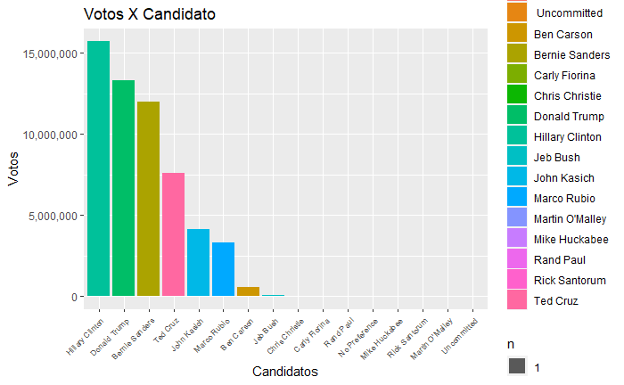

```r
library(ggplot2)
ggplot(data=CantidadVotos,aes(x=reorder(candidate,-Votos),
                              y=Votos,fill = candidate))+
  scale_y_continuous(labels = scales::comma)+
  geom_bar(stat="sum")+
  xlab("Candidatos")+
  ylab("Votos")+
  ggtitle("Votos X Candidato")+
  theme(axis.text.x=element_text(angle=45, hjust=1, size = 7),  legend.position="right")
```

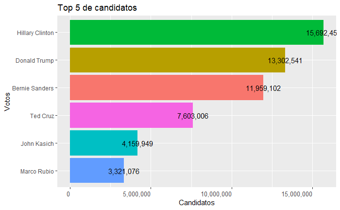

```r
ggplot(data=head(CantidadVotos),aes(y=reorder(candidate,Votos),
                              x=Votos,fill = candidate))+
  scale_x_continuous(labels = scales::comma)+
  geom_bar(stat="sum")+
  xlab("Candidatos")+
  ylab("Votos")+
  ggtitle("Top 5 de candidatos")+
  geom_text(aes(label = scales::comma(as.integer(Votos))))+
  theme(axis.text.x=element_text(angle=0, hjust=1, size = 10),  legend.position="null")
```

### 12. Mostrar los 7 estados con mas afluencia de votaciones

Se muestra la proporción de los 7 estados que tuvieron mayor cantidad de votaciones.

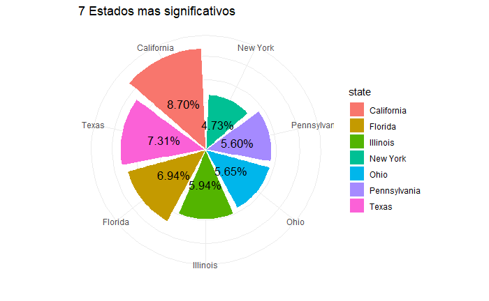

```r
library(scales)
## Obtener Votos por estado y ordenarlos de mayor a menor
VotosPorEstado <- ds.votaciones %>%
  group_by(state) %>%
  summarise(votos=sum(votes)) %>%
  arrange(-votos)
## Obtener total de votos
sumatoriaTotalVotos <- sum(ds.votaciones$votes)
## Proporción de cada estado
VotosPorEstado$proporcion <- (VotosPorEstado$votos)/(sumatoriaTotalVotos)
ggplot(data=head(VotosPorEstado,7),
       aes(y=reorder(state,proporcion),x=proporcion,fill = state))+

    geom_bar(stat = "identity",color="white")+
    geom_text(aes(label=percent(proporcion)),
              position=position_stack(vjust=0.5),color="black",size=4.5)+
    coord_polar(theta = "y")+

    theme_minimal()+
    theme(axis.text.y=element_blank()  # Quitar leyenda del eje vertical
            #,legend.position=""        #Quitar leyenda general
            )+
  ### Etiquetas
    xlab("")+
    ylab("")+
    ggtitle("7 Estados mas significativos")
```